# PostChicago

Angelika Feldmann, Samuel Krall, Belinda Blum

1 June 2026

# 1 Introduction

PostChicago is a toolbox for integrating, annotating, visualising and quantifying Capture-(Hi)-C (from now on Capture-C) data derived from the output of the CHiCAGO pipeline ([Chicago package](https://www.bioconductor.org/packages/release/bioc/html/Chicago.html) [1]).  
The dataset used in this vignette and supplied with the package is from a retinoic-acid (RA) mediated embryonic stem cell (ESC) differentiation ([Mahara et al., 2024](https://doi.org/10.1016/j.molcel.2024.10.005) [2], Capture-C Set1).

```r
library(PostChicago)
```

# 2 Workflow

# 3 Setup

## 3.1 Before you run PostChicago:

PostChicago relies on pre-processed files. This can be done using tools for Hi-C processing up to the point of making filtered-paired `BAM` files, such as [HiCUP](https://www.bioinformatics.babraham.ac.uk/projects/hicup/overview/) [3], followed by creating Chicago input (or `.chinput`) files using the CHiCAGO tools script `bam2chicago.sh`.

Before you use PostChicago, you need the following default directories:

- **dataPath**: Contains chicago input (`.chinput`) files generated from paired `BAM` files by CHiCAGO (`bam2chicago.sh`). Only required in combination with `runChicagoForPostChicago()`
- **chicagoOutputDir**: This is where the output of the CHiCAGO pipeline will be stored. These `chicagoData` objects are required for the PostChicago pipeline
- **designDir**: Contains the 5 design files required by CHiCAGO and described in the CHiCAGO workflow
- **intDir**: Directory containing the intervals of interest, such as ChIP-Seq peaks
- **outputDir**: This is where the output of the PostChicago pipeline will be stored

This is the typical directory structure:

```r
extdata <- system.file("extdata", package = "PostChicago")
dir(extdata)
```

```
#> [1] "dataPath"    "designDir"   "intervals"   "postchicago" "results"
```

```r
path <- file.path(tempdir(), "my_package_output")
dir.create(path, showWarnings = FALSE)

#Before we run PostChicago, we define the default directories first:
dataPath <- file.path(extdata, "dataPath")

designDir <- file.path(extdata, "designDir")
intDir <- file.path(extdata, "intervals")

outputDir <- file.path(path, "postchicago")
dir.create(outputDir)

chicagoOutputDir <- file.path(extdata, "results")

## checking which .chinput files we have stored:
dir(dataPath)
```

```
#> [1] "RA_0h_rep1.chinput"  "RA_0h_rep2.chinput"  "RA_72h_rep1.chinput"
#> [4] "RA_72h_rep2.chinput"
```

```r
## Check if you have already stored the chicagoData tables:
dir(chicagoOutputDir)
```

```
#>  [1] "cd_RA_0h_rep1.rds"          "cd_RA_0h_rep2.rds"
#>  [3] "cd_RA_0h.rds"               "cd_RA_72h_rep1.rds"
#>  [5] "cd_RA_72h_rep2.rds"         "cd_RA_72h.rds"
#>  [7] "fnreadsPerBait"             "gDistrTotIntsPerBait"
#>  [9] "hSigIntsPerBait"            "iDistReadsPerSigIntPerBait"
#> [11] "version2"
```

### 3.1.1 Run CHiCAGO

PostChicago contains the function `runChicagoForPostChicago()` to call on CHiCAGO so that the data is created and named to seamlessly fit into our pipeline. However, `chicagoData` objects can also be created and saved using the standard CHiCAGO pipeline.

- Chicago Settings:  
  We supply embryonic stem cell (ESC) data before (RA_0h) and after (RA_72h) a 72h of retinoic acid (RA) treatment for diffrerentiation to neuronal precursor cells. For our ESC data, we need to modify the standard Chicago settings slightly. The settings depend on your cell type and restriction enzyme and should corerspond to the settings you used for the design files (See CHiCAGO documentation for more). Note that minFragLen and maxFragLen recommendations vary for each enzyme and refer to CHiCAGO documentation for more.

```r
weightsPath <- file.path(
  system.file("extdata", package = "Chicago"),
  "weights"
)
weightSettings <- file.path(weightsPath, "mESC-2reps.settings")
weightSettings <- read.delim(weightSettings, header = FALSE)

mySettings <- Chicago::defaultSettings()
mySettings[grep("weight", names(mySettings))] <- weightSettings[, 2]
mySettings$minFragLen <- 100
```

- Data frame  
  A typical Capture-C experiment consists of several samples and at least two replicates per sample. For full functionality of PostChicago, we advise to run the Chicago pipeline on samples as well as on the individual replicates. We define the sample information in the small dataframe `df`. This table should contain at least two columns: **filename** contains the file names, **type** contains the sample name. All lines with the same sample name will be treated as replicates.  
  Below an example of how we usually construct `df`:

```r
fls <- list.files(dataPath)
fls
```

```
#> [1] "RA_0h_rep1.chinput"  "RA_0h_rep2.chinput"  "RA_72h_rep1.chinput"
#> [4] "RA_72h_rep2.chinput"
```

```r
df <- data.frame(
    filename = fls,
    RA = stringr::str_remove(fls, "_rep.*"),
    rep = stringr::str_remove(stringr::str_remove(fls, "^.*h_"), "\\.chinput$")
)

df$type <- df$RA

head(df)
```

```
#>              filename     RA  rep   type
#> 1  RA_0h_rep1.chinput  RA_0h rep1  RA_0h
#> 2  RA_0h_rep2.chinput  RA_0h rep2  RA_0h
#> 3 RA_72h_rep1.chinput RA_72h rep1 RA_72h
#> 4 RA_72h_rep2.chinput RA_72h rep2 RA_72h
```

Now you can run Chicago!  
Note that for PostChicago we require more than the standard output of the Chicago pipeline. Instead, we save the entire `chicagoData` objects, containing reads and scores for all pairwise interactions, similar to `bedgraph` files. We will require this information for plotting and quantification of interaction strengths for all samples. In contrast, standard Chicago output (`.ibed` files) only saves this information for significant interactions.  
The output will be saved in the `chicagoOutputDir`. The conventional naming of the `chicagoData` objects is `cd_<mysamplename>`. They can later be loaded manually using `load(<myChicagoDataObject>)` and accessed via `cd`.

```r
runChicagoForPostChicago(
    df = df, mySettings = mySettings, outputDir = chicagoOutputDir,
    DataPath = dataPath, DesignDir = designDir
)
```

Running it now on individual replicates. This is recommended for the downstream analysis.

```r
df$type <- as.character(paste(df$RA, df$rep, sep = "_"))

head(df)
```

```
#>              filename     RA  rep        type
#> 1  RA_0h_rep1.chinput  RA_0h rep1  RA_0h_rep1
#> 2  RA_0h_rep2.chinput  RA_0h rep2  RA_0h_rep2
#> 3 RA_72h_rep1.chinput RA_72h rep1 RA_72h_rep1
#> 4 RA_72h_rep2.chinput RA_72h rep2 RA_72h_rep2
```

```r
runChicagoForPostChicago(
    df = df, mySettings = mySettings, outputDir = chicagoOutputDir,
    DataPath = dataPath, DesignDir = designDir
)
```

### 3.1.2 Read in the datasets

Regardless of whether the `chicagoData` objects have been created via `runChicagoForPostChicago()` or via CHiCAGO (or you are using this infrastructure for entirely different data), they will now be loaded into a list.

For this, PostChicago requires two additional objects:

- `baited_genes` is a `GenomicRanges` object that annotates view points and is created from the `.baitmap` (one of the CHiCAGO design files stored in the `designDir`), which allows to easily iterate through the data and add meaningful names to the plots. This object has two mandatory columns: 1.) `re_id` containing the restriction fragment IDs that correspond to the view points (baits) and `.rmap`; 2.) `genename`: name of the bait
- `rmapgr` is a `GenomicRanges` object annotating all restriction fragments and is created from the `.rmap` (one of CHiCAGO design files stored in the `designDir`). The only mandatory column is `id`, containing the ID of the restriction fragment.

To generate `baited_genes` and `rmapgr` objects from design files, we can use the helper functions `baitmap2baited_genes()` and `rmap2rmapgr()`:

```r
baited_genes <- baitmap2baited_genes(designDir, save = FALSE)
rmapgr <- rmap2rmapgr(designDir, save = FALSE)
```

Now we are ready to read in the `chicagoData` tables created by `runChicagoForPostChicago()` into a list using the function `loadCdList()`. We provide precomputed chicagoData objects as examples with the package.

```r
dir(chicagoOutputDir)
```

```
#>  [1] "cd_RA_0h_rep1.rds"          "cd_RA_0h_rep2.rds"
#>  [3] "cd_RA_0h.rds"               "cd_RA_72h_rep1.rds"
#>  [5] "cd_RA_72h_rep2.rds"         "cd_RA_72h.rds"
#>  [7] "fnreadsPerBait"             "gDistrTotIntsPerBait"
#>  [9] "hSigIntsPerBait"            "iDistReadsPerSigIntPerBait"
#> [11] "version2"
```

```r
cdlist <- loadCdList(
             resultsDir = chicagoOutputDir,
             baited_genes = baited_genes
           )
names(cdlist)
```

```
#> [1] "RA_0h_rep1"  "RA_0h_rep2"  "RA_0h"       "RA_72h_rep1" "RA_72h_rep2"
#> [6] "RA_72h"
```

```r
head(cdlist[[1]])
```

```
#> Key: <distSign>
#>     baitID otherEndID         distbin      s_j otherEndLen distSign isBait2bait
#>      <int>      <int>          <fctr>    <num>       <int>    <int>      <lgcl>
#> 1: 3958676    3956226 (9.8e+05,1e+06] 1.766213         259  -998160       FALSE
#> 2: 3958676    3956236 (9.8e+05,1e+06] 1.766213         839  -993798       FALSE
#> 3: 3958676    3956237 (9.8e+05,1e+06] 1.766213         397  -993179       FALSE
#> 4: 3958676    3956241 (9.8e+05,1e+06] 1.766213         336  -991817       FALSE
#> 5: 3958676    3956244 (9.8e+05,1e+06] 1.766213         141  -990455       FALSE
#> 6: 3958676    3956248 (9.8e+05,1e+06] 1.766213         879  -989030       FALSE
#>      N.1     N refBinMean       s_i   NNb NNboe    tlb        tblb       Tmean
#>    <int> <num>      <num>     <num> <num> <num> <fctr>      <fctr>       <num>
#> 1:     1     1  0.3942622 0.8789992     1     1  [0,1] [287,10893] 0.002018329
#> 2:     1     1  0.3942622 0.8789992     1     1  [0,1] [287,10893] 0.002018329
#> 3:     1     1  0.3942622 0.8789992     1     1  [0,1] [287,10893] 0.002018329
#> 4:     1     1  0.3942622 0.8789992     1     1  [0,1] [287,10893] 0.002018329
#> 5:     1     1  0.3942622 0.8789992     1     1  [0,1] [287,10893] 0.002018329
#> 6:     2     2  0.3942622 1.0340367     1     1  (1,2] [287,10893] 0.009652065
#>        Bmean      log.p    log.w     log.q score
#>        <num>      <num>    <num>     <num> <num>
#> 1: 0.6200887 -0.9434607 5.161299 -6.104760     0
#> 2: 0.6247970 -0.9387735 5.167783 -6.106556     0
#> 3: 0.6254691 -0.9381084 5.168705 -6.106813     0
#> 4: 0.6269515 -0.9366448 5.170736 -6.107381     0
#> 5: 0.6284388 -0.9351813 5.172770 -6.107951     0
#> 6: 0.7411193 -1.6944798 5.174900 -6.869380     0
```

```r
pooledSamples <- cdlist[-grep("rep", names(cdlist))]
replicateSamples <- cdlist[grep("rep", names(cdlist))]
rm(cdlist)
```

These steps can also easily be done manually without these helper functions, as long as the input files are organised as such.

# 4 Basic statistics

To assess the quality of the data and individual replicates, PostChicago provides the function `plotSigIntsStats()`. In addition to the summary statistics, such as read counts per sample, this function can plot various distributions across baits using the argument `plotDistribution`. We will omit this step here and set `plotDistribution=FALSE`, since our test dataset only contains one gene. `plotSigIntsStats()` is important to determine inconsistencies that cannot be explained by biology, for instance a sample with a much larger total read number, but a much smaller number of significant interactions. We also find that samples with a high background have a shift in read counts within significant interactions towards a higher read count.

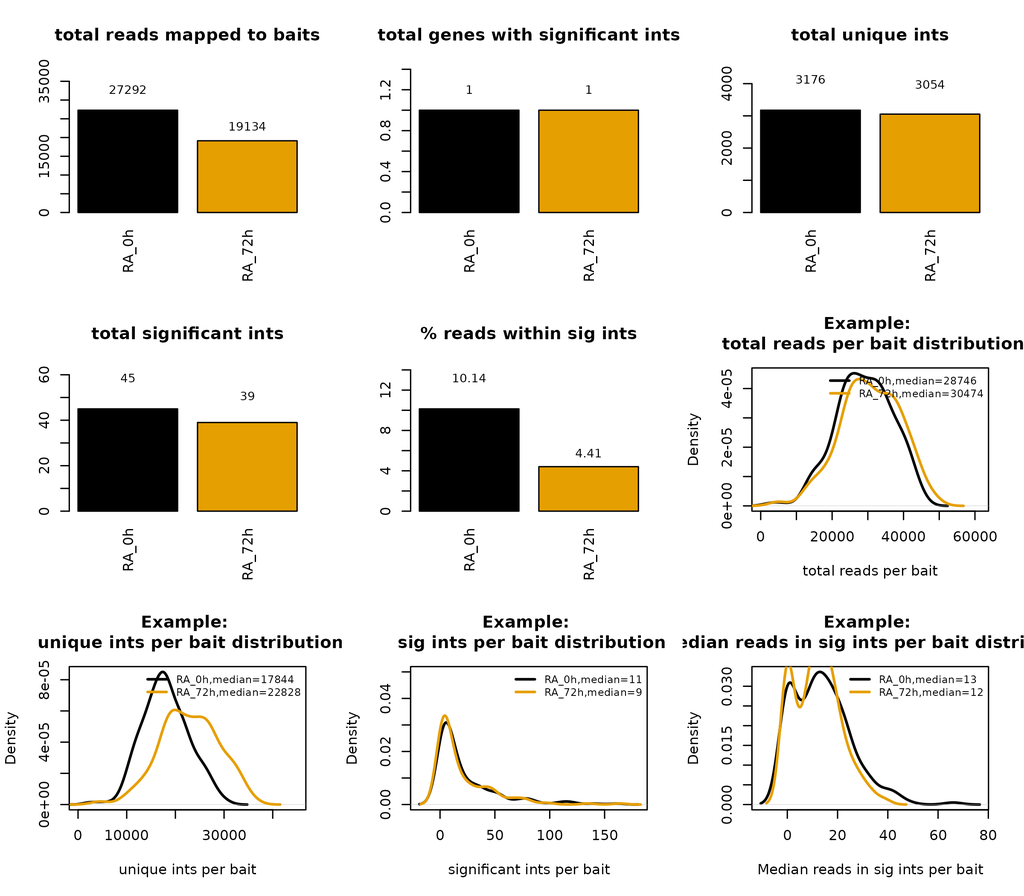

Figure 1: Plots showing basic statistics about out data  
Total reads per condition (top left), nr of genes with significant interactions (top middle), unique interactions (top right), total significant ints (middle left), percentage of reads that are part of significant interactions (true middle), total reads per bait distribution plot (middle right), unique interactions per bait distribution (bottom left), significant interactions per bait density (bottom middle), median reads of each significant interaction per bait distribution plot (bottom right)

```r
plotSigIntsStats(pooledSamples, plotDistribution = FALSE, plotExamples = TRUE)
```

# 5 Visualisation

The main function for data visualisation is `plotInteractions()`.  
This function uses the `chicagoData` objects saved by `runChicagoForPostchicago()` and stored in `L` (samples) or `LL` (replicates) to generate normalised line plots over the genomic location around a view point (bait).

## 5.1 Lineplots

`plotInteractions()` iterates through the list of `chicagoData` tables in `L` or `LL` and plots a running mean read coverage across `k` adjacent fragments surrounding the view point as specified by `id`. The reads are normalized to the total number of reads mapped to baits per 100,000 reads and further to the total number of baits in each capture experiment, which enables a comparison of interactions between different captures. In the plots, the bait position is indicated by the grey triangle. In addition to `k`, we can specify the distance plotted around a bait using the `zoom` argument, with default being +/- 200kb. By default, the plot title contains the `baitID`, `zoom` and `k`, however we can add a more descriptive name, such as the genename of the view point, using the argument `name`.  
The default function creates line plots with bait +/- 200kb:

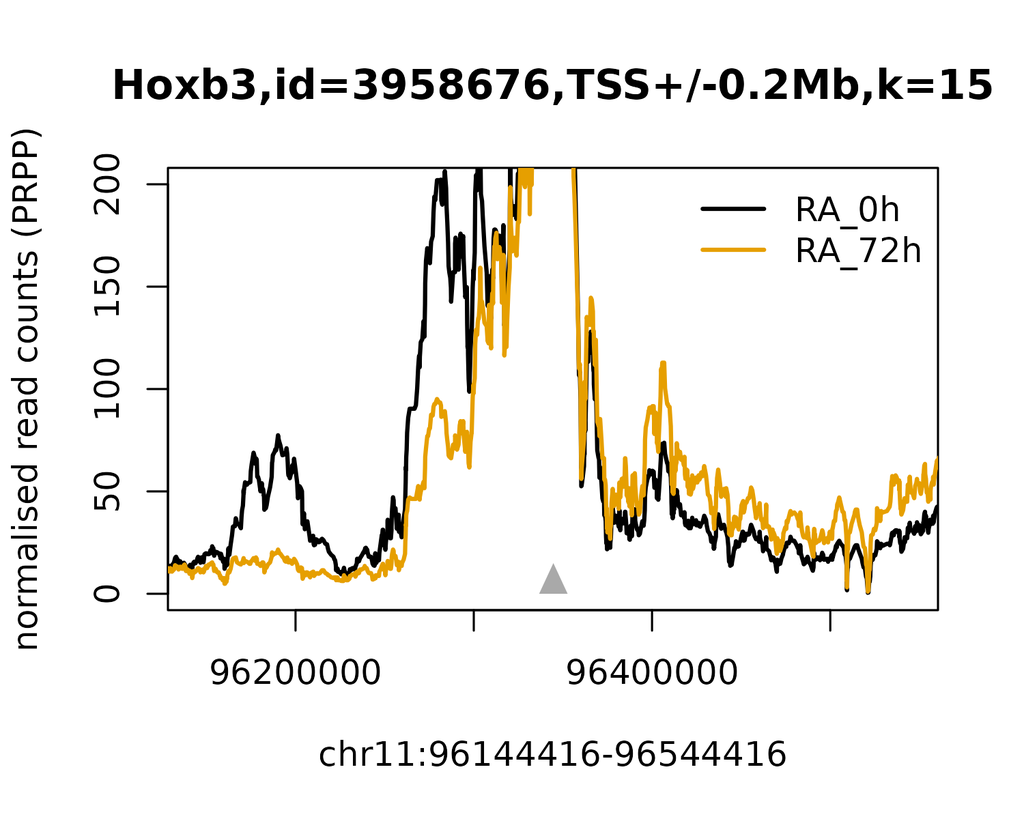

Figure 2: CaptureC signal +/- 200kb around the Hoxb3 gene promoter

```r
col <- palette.colors(2)
name <- "Hoxb3"
id <- baited_genes[baited_genes$genename == name]$re_id
k <- 15
ylim <- c(0, 200)
plotInteractions(pooledSamples, id, k,
    ylim = ylim, show.legend = TRUE, name = name,
    rmapgr = rmapgr, col = col
)
```

The plot above shows a clear difference between the samples with RA_72h strongly losing the interaction on the left. To assess reproducibility, we can now make the plots for individual replicates, stored in the object `LL`. For this, we can keep the sample colours, but redefine the line types using the `lty` option. We can also change the plotted area via `zoom`. For a larger `zoom`, `k` should be adjusted to allow for smooth display of the data:

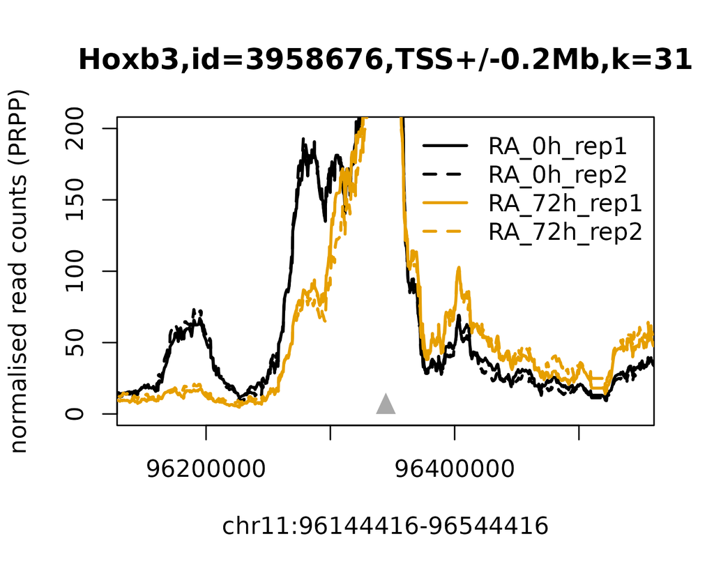

```r
colreps <- rep(col, each = 2)
lty <- rep(1:2, 2)
zoom <- 500000
k <- 31
plotInteractions(replicateSamples, id, k,
    ylim = ylim, show.legend = TRUE, name = name,
    rmapgr = rmapgr, col = colreps, lty = lty
)
```

In addition to changing the `zoom`, which plots the data symmetrically around the bait, we can specify the exact genomic region using `xlim`, which overrides any `zoom` settings. Additionally, the legend can be plotted outside of the plot using the `show.legend.outside` option:

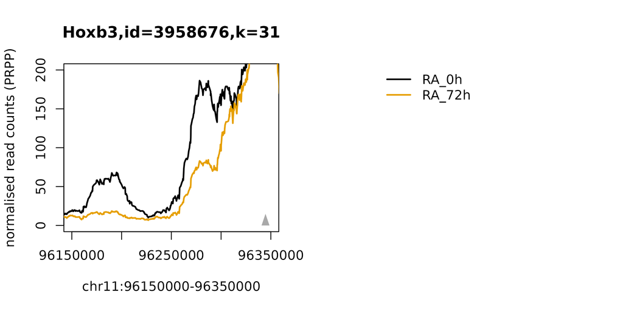

Figure 4: CaptureC signal of Hoxb3 gene promoter within a set interval

```r
par(mfrow = c(1, 2))
xlim <- c(96150000, 96350000)
zoom <- as.numeric(NA)
plotInteractions(pooledSamples, id,
    zoom = zoom, k = k, ylim = ylim, show.legend = FALSE, name = name,
    rmapgr = rmapgr, col = col, show.legend.outside = TRUE, xlim = xlim
)
```

### 5.1.1 Annotation of Line plots with intervals:

Annotation with intervals, such as ChIP-Seq peaks, is generally done from a `GenomicRangesList` object. This can be done manually. For ease of use, PostChicago offers the function `loadGrl()` that automatically constructs the list from either `.rds` or `.bed` files that are supplied in the `intDir`. Let’s load our intervals into a `GenomicRangesList` object `grl`:

```r
dir(intDir)
```

```
#> [1] "K27ac_peaks.bed"  "K27me3_peaks.bed"
```

```r
grl <- loadGrl(intDir = intDir)
```

Intervals in the `grl` can then be added to the line plots using the `intervals` argument:

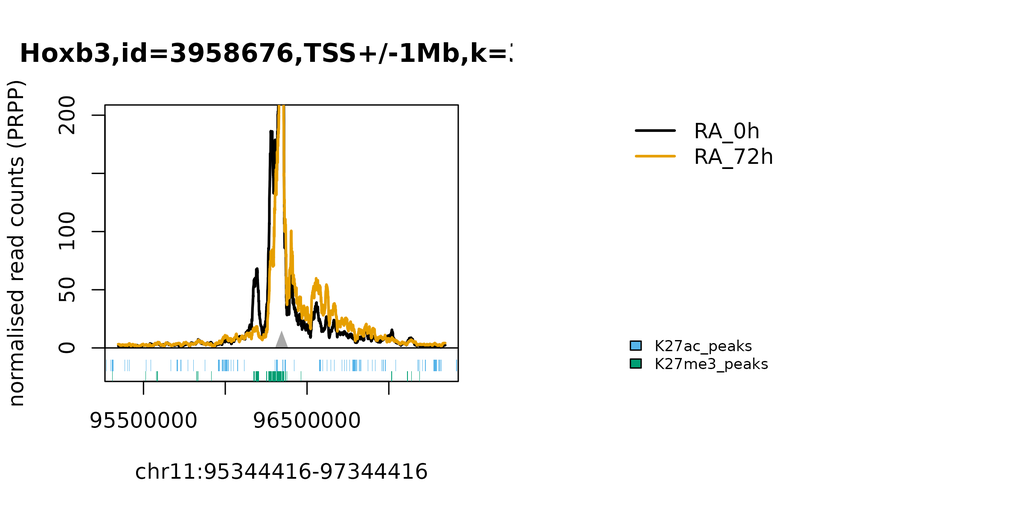

Figure 5: CaptureC signal and ChIP-Seq intervals +/- 1Mb around the Hoxb3 gene promoter  
ChIP-Seq peak intervals are shown below the line plot with H3K27ac peaks shown in blue and H3K27me3 peaks shwon in green

```r
colintervals <- palette.colors(4)[3:4]

zoom <- 1000000

par(mfrow = c(1, 2))
plotInteractions(pooledSamples, id, k,
    zoom = zoom, ylim = ylim, show.legend = FALSE,
    show.legend.intervals = FALSE, name = name,
    intervals = grl, colintervals = colintervals,
    rmapgr = rmapgr, col = col, show.legend.outside = TRUE
)
```

## 5.2 Creating Genome Browser tracks:

Lineplots represent static snap shots. For a more flexible data browsing, PostChicago provides the function `makeBedGraphs()`. Per default, this function creates two types of files for an `id` (= bait): i) `bedgraphs` of normalized interactions for each sample using the same normalisation as for the Lineplots; ii) a `bed` file containing the bait. Unless specified otherwise, using the argument `outputDir`, all files are stored in the default directory called `bedgraphs`.

```r
## extract all view points (baits):
baits <- unique(unlist(lapply(pooledSamples,
                              FUN = function(x) unique(x$baitID))))

## create bedgraphs for selected view points:
for (bait in baits) {
    print(id)
        makeBedGraphs(bait, pooledSamples, rmapgr,
            baited_genes = baited_genes,
            outputDir = paste0(outputDir, "/bedgraphs")
  )
}
```

# 6 Data integration

## 6.1 Create interactions table

To integrate data from multiple samples, we can create an interactions table containing all information about any significant interaction in one experiment using the `makeIntsTable()` function. We first extract all significant interactions across samples, annotate them with raw and pooled weighted average read counts. The reads are then normalized (downsampled) based on the total number of reads mapped to baits across samples (library size). While providing replicate data is optional, for completeness of the analysis we recommend to include data from both pooled samples and replicates, i.e. both `L` and `LL`. The function automatically creates pairwise interaction plots and saves them. Each interaction receives a unique `intID`, which is `baitID;otherEndID`. Since the creation of this table is quite resource-intensive, it is processed in chunks using `ngroups`. For efficient computing time, each group should contain ~50-150 baits. In this experiment, we are processing just one bait, therefore we will process them as ngroups = 1.  
Once saved, the interaction table can be called like any other table in the `.txt` format.

```r
ints <- makeIntsTable(pooledSamples, baited_genes,
        repscores = TRUE, LL = replicateSamples,
        ngroups = 1, outfolder = outputDir
    )
```

Next, we annotate our interactions table with the intervals in `grl` using the `annotateInts()` function. The default requires intervals to have a direct overlap with the otherEnds. This can be changed to being within x bp using the `maxgp` argument, that works similarly to `maxgap` in `findOverlaps()`.

```r
ints <- annotateInts(ints = ints, grl = grl)
```

As quality control of our data, we can use `makeQCplots()`, which plots sample correlations of raw and downsampled read counts and Chicago scores. Two types of heatmaps are made, displaying either overall spearman and pearson correlations or clustering individual interactions.

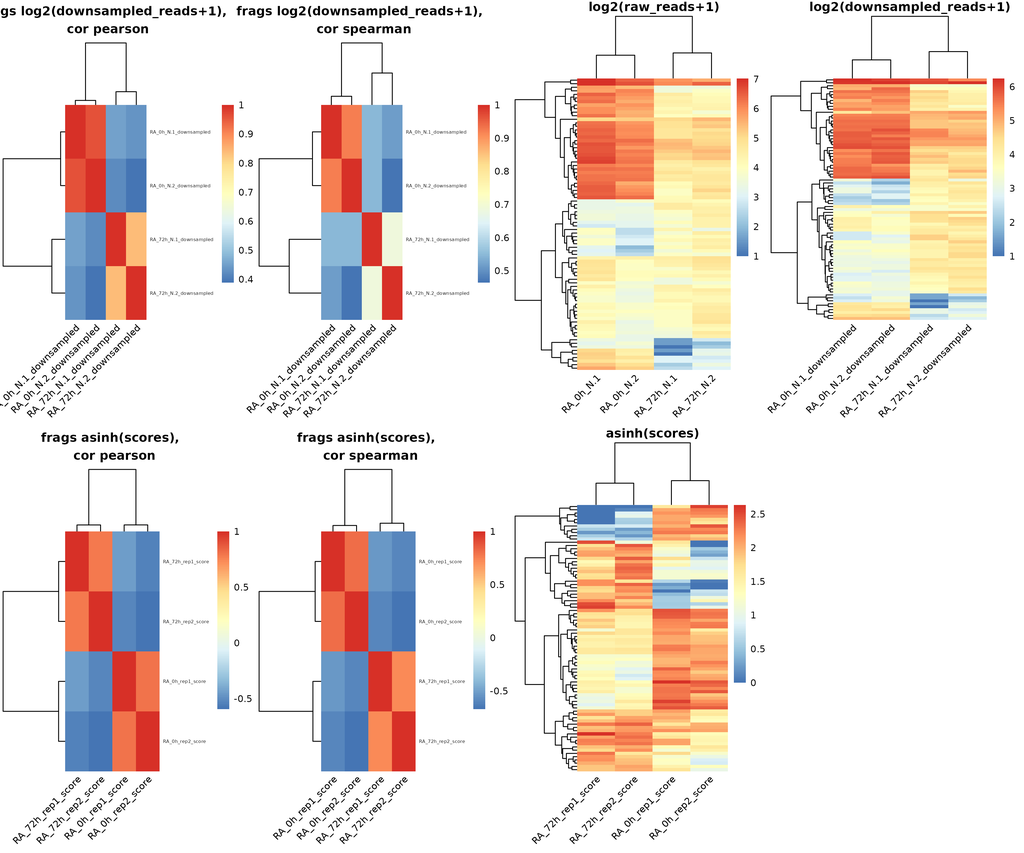

Figure 6: QC heatmaps

```r
makeQCplots(ints, outputDir, fontsize=8)
```

## 6.2 Visualize significant interactions using Lineplots

Significant interactions within the interactions table can be supplied to the `plotInteractions()` function using the argument `d` and visualized as vertical bars:

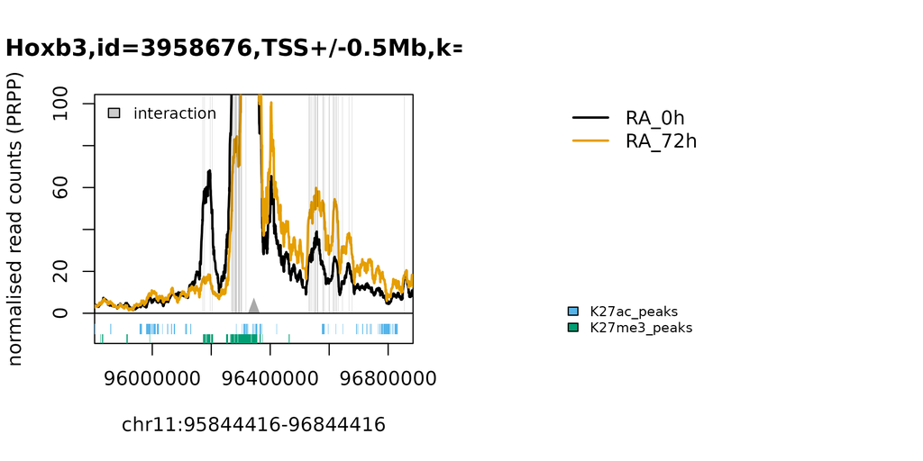

Figure 7: Visualization of significant interactions within lineplots  
Shown is CaptureC signal around the Hoxb3 gene promoter. Significant interactions are shaded.

```r
name <- "Hoxb3"
id <- baited_genes[baited_genes$genename == name]$re_id
k <- 31
zoom <- 500000
ylim <- c(0, 100)

par(mfrow = c(1, 2))
plotInteractions(pooledSamples, id, k, zoom,
        ylim = ylim, show.legend = FALSE,
        show.legend.intervals = FALSE, name = name,
        intervals = grl, colintervals = colintervals,
        rmapgr = rmapgr, col = col,
        show.legend.outside = TRUE, d = ints
    )
```

The function can visualize up to 8 different interaction types using different colors, provided they are annotated in the column called `clusters_refined`. Below an example of how to annotate the interactions table and how to plot these interactions.

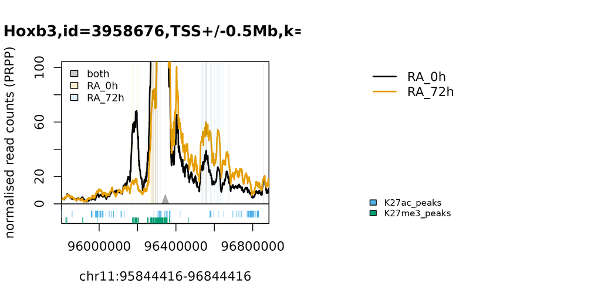

Figure 8: Significant interactions coloured by interaction type

```r
## select interactions detected only at 0h, these are 'lost'
lost <- ints[ints$RA_0h_score >= 5 & ints$RA_72h_score < 3, ]$intID

## select interactions detected only at 72h, these are 'gained'
gained <- ints[ints$RA_0h_score < 3 & ints$RA_72h_score >= 5, ]$intID

## annotate the interaction table with interaction types:
ints$clusters_refined <- "both"
ints[ints$intID %in% lost, ]$clusters_refined <- "RA_0h"
ints[ints$intID %in% gained, ]$clusters_refined <- "RA_72h"

par(mfrow = c(1, 2))
plotInteractions(pooledSamples, id, k, zoom,
    ylim = ylim, show.legend = FALSE,
    show.legend.intervals = FALSE,
    name = name, intervals = grl,
    colintervals = colintervals,
    rmapgr = rmapgr, col = col,
    show.legend.outside = TRUE, d = ints
)
```

# 7 Quantification

## 7.1 Quantification within intervals of interest

So far, we have only compared interactions at the restriction fragment level. However, we are often more interested in interactions with specific intervals, such as ChIP-Seq peaks or gene promoters, which can overlap more than one restriction fragment. To achieve this, we first need to convert our gene-to-fragment interactions into gene-to-peak interactions.

### 7.1.1 Making oneGeneOnePeak tables

The first step is to create `oneGeneOnePeak` tables using the function `makeOneGeneOnePeak()`. Interactions with large intervals, such as ChIP-Seq peaks, can have multiple fragment-level interactions. In contrast, interval interactions within `oneGeneOnePeak` tables assign only one interaction per specific interval per gene. These interaction tables are automatically saved in the directory defined in the argument `folder`.

```r
quantfolder <- paste0(outputDir, "/oneGeneOnePeak")
ogoplist <- makeOneGeneOnePeak(grl = grl, rmapgr = rmapgr,
                               ints = ints, folder = quantfolder)
```

```
#> processing K27ac_peaks...
#> Interval overlaps resolved
#> Interactions overlapped with intervals
#> OneGeneOnePeak table created
#> Summits annotated
#> processing K27me3_peaks...
#> Interval overlaps resolved
#> Interactions overlapped with intervals
#> OneGeneOnePeak table created
#> Summits annotated
```

```r
##look at the oneGeneOnePeak tables:
ogoplist[[1]][1:2,]
```

```
#>                                                   intID  baitID
#> 3958676;3958519 3958676;3958519,3958520,3958521,3958522 3958676
#> 3958676;3958526 3958676;3958526,3958527,3958528,3958529 3958676
#>                                      otherEndID seqnames_bait start_bait
#> 3958676;3958519 3958519,3958520,3958521,3958522         chr11   96343553
#> 3958676;3958526 3958526,3958527,3958528,3958529         chr11   96343553
#>                 end_bait seqnames_otherEnd start_otherEnd end_otherEnd
#> 3958676;3958519 96345280             chr11       96283263     96285534
#> 3958676;3958526 96345280             chr11       96286496     96289482
#>                 interval_id_K27ac_peaks seqnames_K27ac_peaks start_K27ac_peaks
#> 3958676;3958519                    2740                chr11          96284201
#> 3958676;3958526                    2741                chr11          96286770
#>                 end_K27ac_peaks summit_re_id
#> 3958676;3958519        96285181      3958521
#> 3958676;3958526        96287453      3958527
```

```r
##The tables are also saved in the quantfolder:
list.files(path = quantfolder, pattern = "oneGeneOnePeak")
```

```
#> [1] "oneGeneOnePeak_K27ac_peaks_interacting.txt"
#> [2] "oneGeneOnePeak_K27me3_peaks_interacting.txt"
```

**Examples:**

We can visualize `oneGeneOnePeak` interactions with `plotInteractions()` by supplying `oneGeneOnePeak` tables instead of the original interactions table via the argument `d`:

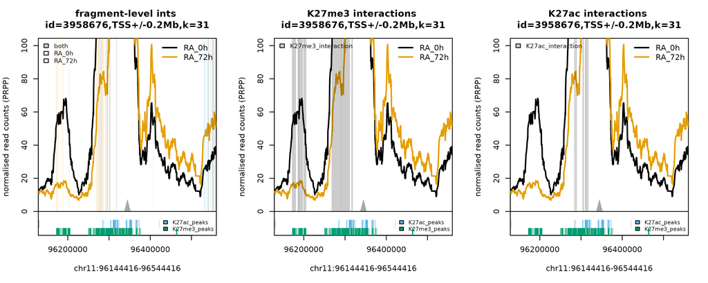

Figure 9: Visualization of oneGeneOnePeak interactions  
All (left), H3K27me3 (middle) and H3K27ac (right) associated interactions are shaded.

```r
fls_ogop <- list.files(path = quantfolder, pattern = "oneGeneOnePeak")

## Load oneGeneOnePeak file for H3K27me3 peaks:
ogop_K27me3 <- read.delim(paste(quantfolder,
                                fls_ogop[grep("K27me3", fls_ogop)],sep = "/"),
                          stringsAsFactors = FALSE)
ogop_K27me3$clusters_refined <- "K27me3_interaction"

## Load oneGeneOnePeak file for H3K27ac peaks:
ogop_K27ac <- read.delim(paste(quantfolder,
                               fls_ogop[grep("K27ac", fls_ogop)],sep = "/"),
                          stringsAsFactors = FALSE)
ogop_K27ac$clusters_refined <- "K27ac_interaction"

par(mfrow = c(1, 3))

## all interactions:
plotInteractions(pooledSamples, id, k,
    ylim = ylim, show.legend = TRUE,
    name = paste("fragment-level ints \n", sep = ","),
    colintervals = colintervals, intervals = grl,
    rmapgr = rmapgr, col = col, d = ints
)

## K27me3-overlapping interactions
plotInteractions(pooledSamples, id, k,
  ylim = ylim, show.legend = TRUE,
  name = paste("K27me3 interactions \n", sep = ","),
  intervals = grl, rmapgr = rmapgr, col = col,
  colintervals = colintervals, d = ogop_K27me3
)

## K27ac-overlapping interactions
plotInteractions(pooledSamples, id, k,
    ylim = ylim, show.legend = TRUE,
    name = paste("K27ac interactions \n", sep = ","),
    intervals = grl, colintervals = colintervals,
    rmapgr = rmapgr, col = col, d = ogop_K27ac
)
```

### 7.1.2 Matrices surrounding intervals of interest

Now that we have our oneGeneOnePeak files, we will quantify reads and scores under Hoxb3 promoter-interacting H3K27ac peaks. To do this, we will first create interaction matrices centered at restriction fragment overlapping the center of interacting ranges using the function `getMatrix()`. The distance from center in restriction fragments is given via the argument `zoom`. The default function creates `Lm`, a list of matrices based on the supplied list of `chicagoData` objects. This list contains matrices with ranges overlaps across all samples and distance-matched control matrices. The matrices are flipped in a way that the promoter is always to the right of the interaction. `Lm` is saved within the `resfolder` and can be loaded into an object called `Lm`.  
As an example, we will now create such matrices for H3K27ac peaks.

```r
name <- names(grl)[grep("K27ac", names(grl))]
name
```

```
#> [1] "K27ac_peaks"
```

```r
## Zoom defines the +/- distance (in restriction fragments) around the intervals
## for which the matrices will be created
zoom <- 100

## Folder in which the matrices will be stored:
resfolder <- paste0(outputDir, "/matrices/")
if (!file.exists(resfolder)) {
    dir.create(resfolder)
}

## un-normalized matrix with reads
m_reads <- getMatrix(pooledSamples,
    zoom = zoom, d = ogop_K27ac, resfolder = resfolder, type = "reads",
    norm = FALSE, name = name, rmapgr = rmapgr
)

## matrix normalized to the center of interactions
## in sample 1 (as defined per normsam) with reads
m_reads_norm <- getMatrix(pooledSamples,
    zoom = zoom, d = ogop_K27ac, resfolder = resfolder, type = "reads",
    norm = TRUE, name = name, rmapgr = rmapgr, normsam = 1
)

## matrix normalized to the center of interactions
## in sample 2 (as defined per normsam) with reads
m_reads_norm2 <- getMatrix(pooledSamples,
    zoom = zoom, d = ogop_K27ac, resfolder = resfolder, type = "reads",
    norm = TRUE, name = name, rmapgr = rmapgr, normsam = 2
)

## un-normalized matrix with scores
m_scores <- getMatrix(pooledSamples,
    zoom = zoom, d = ogop_K27ac, resfolder = resfolder, type = "scores",
    norm = FALSE, name = name, rmapgr = rmapgr
)

## matrix normalized to the center of interactions
## in sample 1 (as defined per normsam) with scores
m_scores_norm <- getMatrix(pooledSamples,
    zoom = zoom, d = ogop_K27ac, resfolder = resfolder, type = "scores",
    norm = TRUE, name = name, rmapgr = rmapgr, normsam = 1
)

## matrix normalized to the center of interactions
## in sample 2 (as defined per normsam) with scores
m_scores_norm2 <- getMatrix(pooledSamples,
    zoom = zoom, d = ogop_K27ac, resfolder = resfolder, type = "scores",
    norm = TRUE, name = name, rmapgr = rmapgr, normsam = 2
)
```

### 7.1.3 Plotting aggregate profiles of interactions

Now we can use the lists of matrices to plot aggregate profiles of different interaction types using the `plotAggregatePeaks()` function. We are plotting aggregate read counts over all interactions. Then we will plot normalised read counts to one of the samples, which makes individual interactions more comparable.

```r
## Loading precomputed matrices:
name <- names(grl)[grep("K27ac", names(grl))]
name
```

```
#> [1] "K27ac_peaks"
```

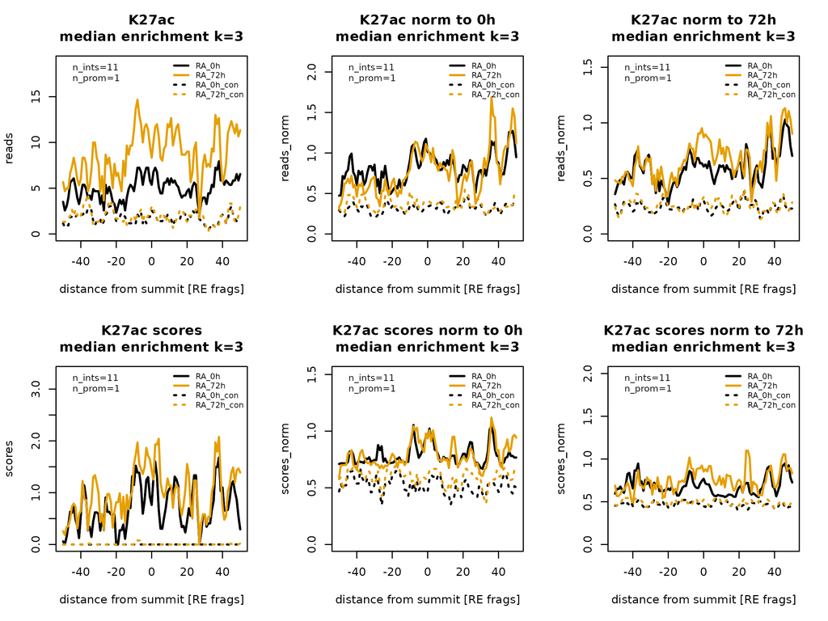

Figure 10: Aggregate CaptureC profiles  
Reads (top) or scores (bottom) were aggregated for all interactions overlapping H3K27ac peaks. Dotted lines: Distance-matched background. Note that the data will compare differently according to normalisation, as shown with no normalisation (left) or to either dataset (middle and right)

```r
## Plots:

colaggr <- rep(col, 2)
lty <- rep(c(1, 3), each = 2)

par(mfrow = c(2, 3))

plotAggregatePeaks(m_reads,
    plotwhat = "median", k = 3, xlim = c(-50, 50),
    mainprefix = "K27ac\n", ylab = "reads",
    col = colaggr, lty = lty
)

plotAggregatePeaks(m_reads_norm,
    plotwhat = "median", k = 3, xlim = c(-50, 50),
    mainprefix = "K27ac norm to 0h\n", ylab = "reads_norm",
    col = colaggr, lty = lty
)

plotAggregatePeaks(m_reads_norm2,
    plotwhat = "median", k = 3, xlim = c(-50, 50),
    mainprefix = "K27ac norm to 72h\n", ylab = "reads_norm",
    col = colaggr, lty = lty
)

plotAggregatePeaks(m_scores,
    plotwhat = "median", k = 3, xlim = c(-50, 50),
    mainprefix = "K27ac scores\n", ylab = "scores",
    col = colaggr, lty = lty
)

plotAggregatePeaks(m_scores_norm,
    plotwhat = "median", k = 3, xlim = c(-50, 50),
    mainprefix = "K27ac scores norm to 0h\n",
    ylab = "scores_norm",
    col = colaggr, lty = lty
)

plotAggregatePeaks(m_scores_norm2,
    plotwhat = "median", k = 3, xlim = c(-50, 50),
    mainprefix = "K27ac scores norm to 72h\n",
    ylab = "scores_norm",
    col = colaggr, lty = lty
)
```

The above plots show that Hoxb3 interactions with H3K27ac increase upon differentiation, with subtle differences depending on the sample to which the data are normalised. For sanity check, we recommend to test out normalisation to different samples. Also, to avoid inflation of fold changes, a general recommendation is to use the positive control sample as reference.  
Let’s compare Hoxb3 interactions with H3K27ac peaks with its H3K27me3 peak interactions:

```r
name <- names(grl)[grep("K27me3", names(grl))]
name
```

```
#> [1] "K27me3_peaks"
```

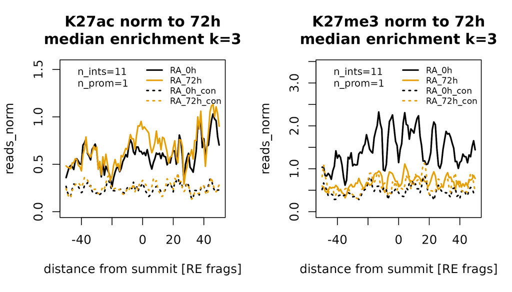

Figure 11: Aggregated interaction signal at different peak sets  
Shown is the aggregated interaction signal at K27ac peaks (left) and K27me3 peaks (right).

```r
## matrix normalized to the center of interactions
## in sample 2 (as defined per normsam) with reads
m_reads_norm2_K27me3 <- getMatrix(pooledSamples,
    zoom = zoom, d = ogop_K27me3, resfolder = resfolder,
    type = "reads", norm = TRUE,
    name = name, rmapgr = rmapgr, normsam = 2
)

# Plots:

colaggr <- rep(col, 2)
lty <- rep(c(1, 3), each = 2)

par(mfrow = c(1, 2))
plotAggregatePeaks(m_reads_norm2,
    plotwhat = "median", k = 3,
    xlim = c(-50, 50),
    mainprefix = "K27ac norm to 72h\n",
    ylab = "reads_norm", col = colaggr, lty = lty
)

plotAggregatePeaks(m_reads_norm2_K27me3,
    plotwhat = "median", k = 3,
    xlim = c(-50, 50),
    mainprefix = "K27me3 norm to 72h\n",
    ylab = "reads_norm", col = colaggr, lty = lty
)
```

This comparison shows that while the Hoxb3 promoter gains interactions with H3K27ac peaks, it loses interactions with H3K27me3 peaks, consistent with the line plots.  
`getMatrix()` can use two types of read normalisation: downsampling (default) and scaling. In both cases reads are normalised to the read coverage, but in case of scaling, the reads are scaled by the total number of promoters in the Capture experiment upon downsampling to a default library size of 100,000. This is meant to enable comparison between different capture experiments and works in the same way as read normalization in `plotInteractions()`. On the other hand, in case of downsampling, the reads are simply downsampled to the smallest library in `L`.  
Below is a comparison of the two read normalisation methods:

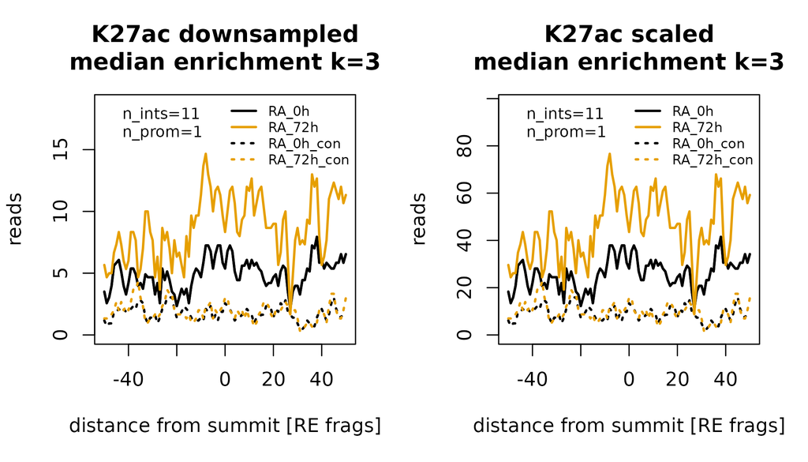

Figure 12: Aggregate profiles for different normalizations  
Downsampling (left) normalizes read counts within one experiment, whereas scaling (right) further normalizes to the number of capture view points making the signal comparable across experiments.

```r
## matrix with scaling reads:
m_reads_scaling <- getMatrix(pooledSamples, zoom, ogop_K27ac,
    resfolder = resfolder, type = "reads", norm = FALSE,
    name = name, rmapgr = rmapgr, readnorm = "scaling"
)

## plots:
par(mfrow = c(1, 2))
plotAggregatePeaks(m_reads,
    plotwhat = "median", k = 3,
    xlim = c(-50, 50),
    mainprefix = "K27ac downsampled\n",
    ylab = "reads", col = colaggr, lty = lty
)

plotAggregatePeaks(m_reads_scaling,
    plotwhat = "median", k = 3,
    xlim = c(-50, 50),
    mainprefix = "K27ac scaled\n",
    ylab = "reads", col = colaggr, lty = lty
)
```

### 7.1.4 Quantify reads in epigenetic peak interactions directly

```r
fls_ogop <- list.files(path = quantfolder, pattern = "oneGeneOnePeak")

## Load oneGeneOnePeak file for H3K27me3 peaks:
ogop_K27me3 <- read.delim(paste(quantfolder, fls_ogop[grep("K27me3", fls_ogop)],
                sep = "/"), stringsAsFactors = FALSE)
ogop_K27me3$clusters_refined <- "K27me3 interaction"

## Quantify
annotatedTable <- quantifyWithinPeaks(data = ogop_K27me3,
                                      cdlist = pooledSamples,
                                      cdlist.reps = replicateSamples,
                                      rmapgr = rmapgr,
                                      minsize = 100,
                                      maxsize = 40000,
                                      file = paste0(outputDir,
                                                   '/aggregated5_annotated.txt')
                                      )

##Look at the oneGeneOnePeak table before...
ogop_K27me3[c(2,4),]
```

```
#>                                                                                                   intID
#> 3958676;3958290                                 3958676;3958285,3958286,3958287,3958288,3958289,3958290
#> 3958676;3958308 3958676;3958301,3958302,3958303,3958304,3958305,3958306,3958307,3958308,3958309,3958310
#>                  baitID
#> 3958676;3958290 3958676
#> 3958676;3958308 3958676
#>                                                                                      otherEndID
#> 3958676;3958290                                 3958285,3958286,3958287,3958288,3958289,3958290
#> 3958676;3958308 3958301,3958302,3958303,3958304,3958305,3958306,3958307,3958308,3958309,3958310
#>                 seqnames_bait start_bait end_bait seqnames_otherEnd
#> 3958676;3958290         chr11   96343553 96345280             chr11
#> 3958676;3958308         chr11   96343553 96345280             chr11
#>                 start_otherEnd end_otherEnd interval_id_K27me3_peaks
#> 3958676;3958290       96185035     96188091                      833
#> 3958676;3958308       96193579     96197868                      835
#>                 seqnames_K27me3_peaks start_K27me3_peaks end_K27me3_peaks
#> 3958676;3958290                 chr11           96185872         96187448
#> 3958676;3958308                 chr11           96193727         96197451
#>                 summit_re_id   clusters_refined
#> 3958676;3958290      3958286 K27me3 interaction
#> 3958676;3958308      3958305 K27me3 interaction
```

```r
##and after the annotation
annotatedTable[c(2,4),]
```

```
#>                                                                                                   intID
#> 3958676;3958290                                 3958676;3958285,3958286,3958287,3958288,3958289,3958290
#> 3958676;3958308 3958676;3958301,3958302,3958303,3958304,3958305,3958306,3958307,3958308,3958309,3958310
#>                  baitID
#> 3958676;3958290 3958676
#> 3958676;3958308 3958676
#>                                                                                      otherEndID
#> 3958676;3958290                                 3958285,3958286,3958287,3958288,3958289,3958290
#> 3958676;3958308 3958301,3958302,3958303,3958304,3958305,3958306,3958307,3958308,3958309,3958310
#>                 seqnames_bait start_bait end_bait seqnames_otherEnd
#> 3958676;3958290         chr11   96343553 96345280             chr11
#> 3958676;3958308         chr11   96343553 96345280             chr11
#>                 start_otherEnd end_otherEnd interval_id_K27me3_peaks
#> 3958676;3958290       96185035     96188091                      833
#> 3958676;3958308       96193579     96197868                      835
#>                 seqnames_K27me3_peaks start_K27me3_peaks end_K27me3_peaks
#> 3958676;3958290                 chr11           96185872         96187448
#> 3958676;3958308                 chr11           96193727         96197451
#>                 summit_re_id   clusters_refined RA_0h_N RA_72h_N RA_0h_score
#> 3958676;3958290      3958286 K27me3 interaction      96       21    14.18701
#> 3958676;3958308      3958305 K27me3 interaction     190       36    29.29070
#>                 RA_72h_score RA_0h_rep1_N RA_0h_rep2_N RA_72h_rep1_N
#> 3958676;3958290    0.5794752          114           73             9
#> 3958676;3958308    0.8786127          204          173            27
#>                 RA_72h_rep2_N RA_0h_rep1_score RA_0h_rep2_score
#> 3958676;3958290            31         11.57119         7.802664
#> 3958676;3958308            44         20.69339        19.710040
#>                 RA_72h_rep1_score RA_72h_rep2_score RA_0h_N_downsampled
#> 3958676;3958290        0.01487077          1.757567            67.29739
#> 3958676;3958308        0.28359772          2.171456           133.19275
#>                 RA_72h_N_downsampled RA_0h_rep1_N_downsampled
#> 3958676;3958290              20.9979                 63.91074
#> 3958676;3958308              35.9964                114.36659
#>                 RA_0h_rep2_N_downsampled RA_72h_rep1_N_downsampled
#> 3958676;3958290                 55.29819                    8.9991
#> 3958676;3958308                131.04913                   26.9973
#>                 RA_72h_rep2_N_downsampled totalValidFrags
#> 3958676;3958290                  26.25129               5
#> 3958676;3958308                  37.25989               9
#>                 RA_0h_N_downsampled_mean RA_72h_N_downsampled_mean
#> 3958676;3958290                 13.45948                   4.19958
#> 3958676;3958308                 14.79919                   3.99960
#>                 RA_0h_rep1_N_downsampled_mean RA_0h_rep2_N_downsampled_mean
#> 3958676;3958290                      12.78215                      11.05964
#> 3958676;3958308                      12.70740                      14.56101
#>                 RA_72h_rep1_N_downsampled_mean RA_72h_rep2_N_downsampled_mean
#> 3958676;3958290                        1.79982                       5.250257
#> 3958676;3958308                        2.99970                       4.139988
#>                 RA_0h_score_mean RA_72h_score_mean RA_0h_rep1_score_mean
#> 3958676;3958290         2.837403        0.11589505              2.314238
#> 3958676;3958308         3.254522        0.09762363              2.299265
#>                 RA_0h_rep2_score_mean RA_72h_rep1_score_mean
#> 3958676;3958290              1.560533            0.002974155
#> 3958676;3958308              2.190004            0.031510858
#>                 RA_72h_rep2_score_mean
#> 3958676;3958290              0.3515134
#> 3958676;3958308              0.2412729
```

Let’s now plot our quantification as boxplots using the function `boxplotsCapC()`:

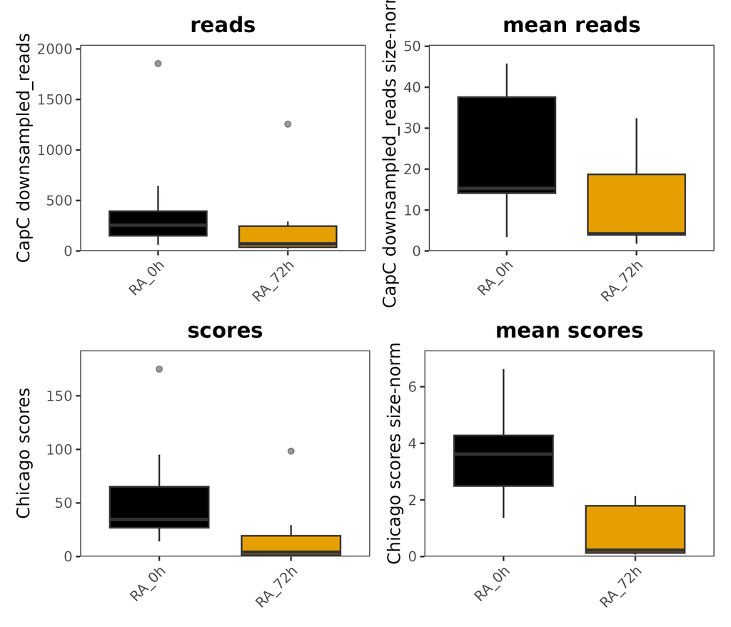

Figure 13: Boxplots for quantitative comparison of CaptureC signal  
Two types of read or score quantification is provided that give slightly different results: (i) Total signal within a oneGeneOnePeak interaction (left) (ii) Total signal normalized to the number of restriction fragments within which the reads were quantified (right).

```r
##plot samples:
boxplotsCapC(annotatedTable, col=col, show_notch = FALSE)
```

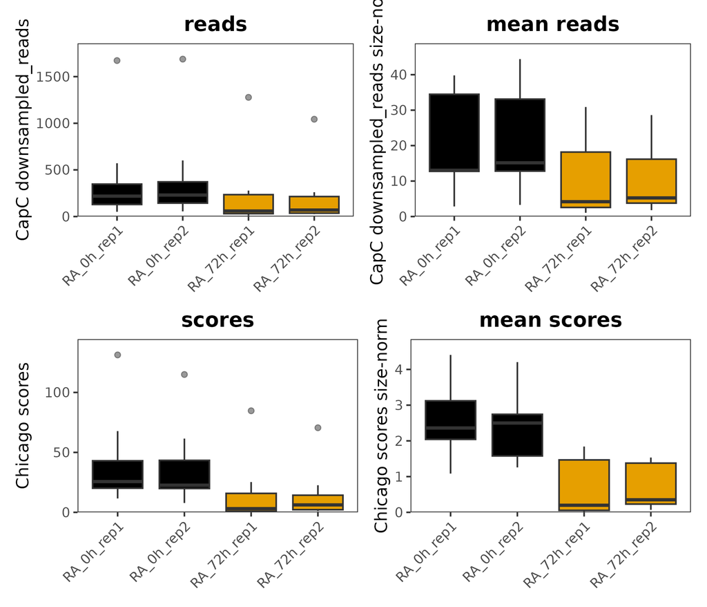

Figure 14: Boxplots for quantitative comparison of CaptureC signal  
Two types of read or score quantification is provided that give slightly different results: (i) Total signal within a oneGeneOnePeak interaction (left) (ii) Total signal normalized to the number of restriction fragments within which the reads were quantified (right).

```r
##plot replicate data:
boxplotsCapC(annotatedTable, col=rep(col,each=2),
             reps=TRUE, show_notch = FALSE
)
```

## 7.2 Data integration to interaction peaks

Visualizing interactions, for instance in line plots, quickly reveals that one strong interaction peak can actually be represented by multiple disjointed interactions. These interactions can be merged using the `aggregatePeaks()` function of PostChicago. This function takes a table of interactions and merges all otherEnds interacting with one bait that are within a distance of `dis` restriction fragments of each other.  
If we would like to define **sample-specific interaction peaks**, the supplied table should contain only these sample-specific interactions.  
Below is a comparison of fragment-level interactions with interactions aggregated over 5 restriction sites:

```r
## Define names of significant interactions shown in the plot
ints$clusters_refined <- "interaction"

## Distance in restriction fragments over which to aggregate:
dis <- 5

## Let's aggregate all interactions within 5 fragments distance of each other:
aggregated5 <- aggregatePeaks(ints, dis, names(pooledSamples),
    fileprefix = "ints", outdir = outputDir
)
```

```
#> dis 5 , aggregating peaks...
```

```r
## Let's aggregate all interactions within 5 fragments distance of each other
## that are significant at 0h:
aggregated5_0h <- aggregatePeaks(ints[ints$RA_0h_score >= 5, ], dis,
    names(pooledSamples),
    fileprefix = "ints_0h", outdir = outputDir
)
```

```
#> dis 5 , aggregating peaks...
```

```r
## Let's aggregate all interactions within 5 fragments distance of each other
## that are significant at 72h:
aggregated5_72h <- aggregatePeaks(ints[ints$RA_72h_score >= 5, ], dis,
  names(pooledSamples),
  fileprefix = "ints_72h",
  outdir = outputDir
)
```

```
#> dis 5 , aggregating peaks...
```

```r
nrow(ints)
```

```
#> [1] 82
```

```r
nrow(aggregated5)
```

```
#> [1] 35
```

```r
nrow(aggregated5_0h)
```

```
#> [1] 16
```

```r
nrow(aggregated5_72h)
```

```
#> [1] 23
```

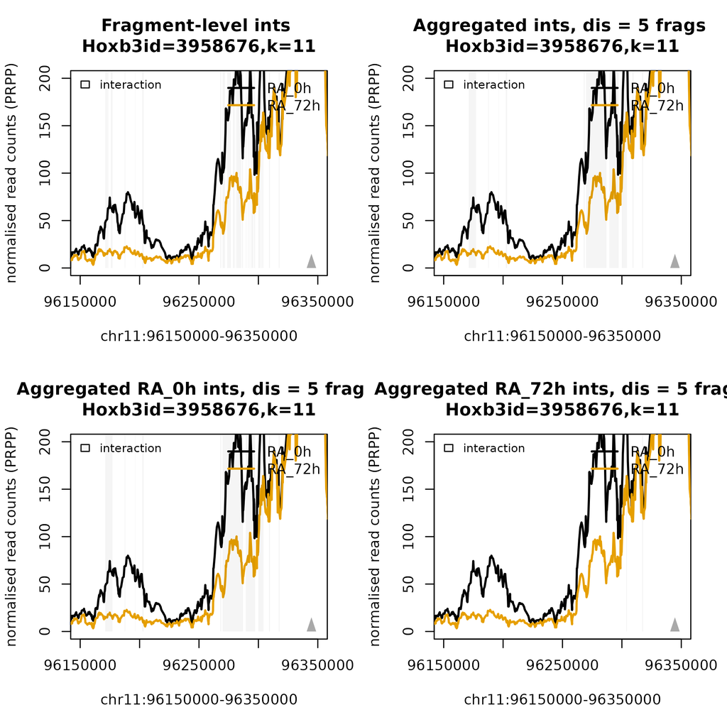

Figure 15: Lineplots with different types of interactions  
Interactions are shaded, either fragment-fragment (top left), aggregated over all significant interactions within 5 restriction fragments (top right), and aggregated over significant interactions within 5 restriction fragments either in ESCs (RA_0h, bottom left) or in NP (RA_72h, bottom right).

```r
## Example plots:
col <- palette.colors(2)
name <- "Hoxb3"
id <- baited_genes[baited_genes$genename == name]$re_id
k <- 11
ylim <- c(0, 200)
xlim <- c(96150000, 96350000)
zoom <- as.numeric(NA)
colints <- rgb(0, 0, 0, 0.2)

par(mfrow = c(2, 2))

plotInteractions(pooledSamples, id, k, zoom,
    ylim = ylim, show.legend = TRUE,
    name = paste("Fragment-level ints \n", name, sep = ""),
    rmapgr = rmapgr, col = col, d = ints,
    xlim = xlim, colints = colints
)

plotInteractions(pooledSamples, id, k, zoom,
    ylim = ylim, show.legend = TRUE,
    name = paste("Aggregated ints, dis = ", dis, " frags \n", name, sep = ""),
    rmapgr = rmapgr, col = col, d = aggregated5,
    xlim = xlim, colints = colints
)

plotInteractions(pooledSamples, id, k, zoom,
    ylim = ylim, show.legend = TRUE,
    name = paste("Aggregated RA_0h ints, dis = ", dis, " frags \n", name, sep = ""),
    rmapgr = rmapgr, col = col, d = aggregated5_0h,
    xlim = xlim, colints = colints
)

plotInteractions(pooledSamples, id, k, zoom,
    ylim = ylim, show.legend = TRUE,
    name = paste("Aggregated RA_72h ints, dis = ", dis, " frags \n", name, sep = ""),
    rmapgr = rmapgr, col = col, d = aggregated5_72h,
    xlim = xlim, colints = colints
)
```

This visualization nicely confirms that, as suspected from the interaction profiles, the majority of interactions in this region are specific for RA_0h.  
Apart from fragment-level aggregation, PostChicago provides the function `aggregatePeaks_regions()`, which aggregates significant interactions based on the distance in bp. Below an example on how peak aggregation works over a 10kb distance.

```r
## Distance in bp over which to aggregate:
disbp <- 10000

## Let's aggregate all interactions within 5 fragments distance of each other:
aggregated10kb <- aggregatePeaks_regions(ints, disbp, names(L),
    fileprefix = "ints",
    outdir = outputDir
)
```

```
#> distance of 10000 , aggregating peaks...
```

```r
nrow(aggregated10kb)
```

```
#> [1] 11
```

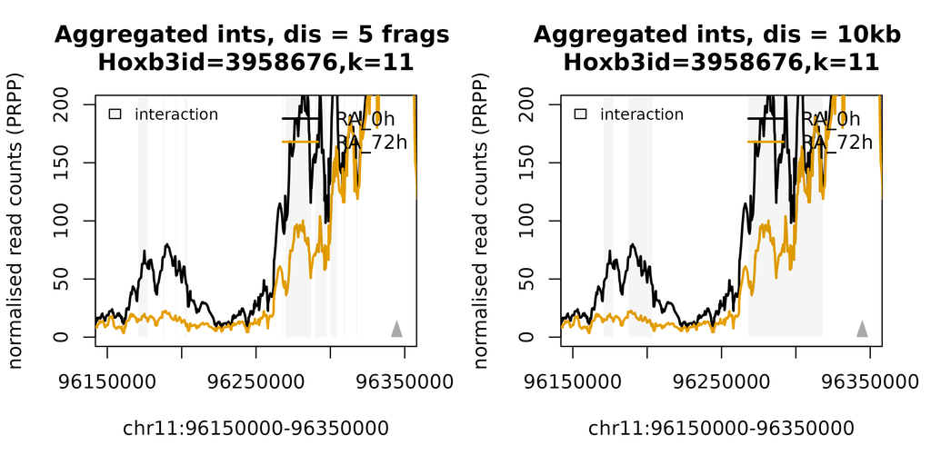

```r
## plot:
par(mfrow = c(1, 2))
plotInteractions(pooledSamples, id, k, zoom,
    ylim = ylim, show.legend = TRUE,
    name = paste("Aggregated ints, dis = ", dis,
                 " frags \n", name, sep = ""),
    rmapgr = rmapgr, col = col, d = aggregated5,
    xlim = xlim, colints = colints
)
plotInteractions(pooledSamples, id, k, zoom,
    ylim = ylim, show.legend = TRUE,
    name = paste("Aggregated ints, dis = ", disbp / 1000,
                 "kb \n", name, sep = ""),
    rmapgr = rmapgr, col = col, d = aggregated10kb,
    xlim = xlim, colints = colints
)
```

These examples reveal that while an aggregation over 10kb nicely highlights the two interaction peaks at the lost interaction on the left, the interactions more proximally to the view point lose their granularity with such harsh aggregation. As with peak calling for ChIP-Seq, we recommend testing out different aggregation types and distances for each new Capture experiment.  
Interaction peaks can now be used to create new grl objects for oneGeneOnePeak-level analysis analogous to the analysis for epigenetic ranges.

## 7.3 Direct quantification within interaction peaks

Interaction peaks summarize multiple significant interactions within a peak. Accurate quantification of all signal under the interaction peaks includes quantification of reads and scores within restriction fragments that are covered, but not necessarily contain significant interactions and are therefore not part of our original interaction table.  
Such quantification can be done using the oneGeneOnePeak-level analysis which requires creating a matrix following signal quantification from the matrix, as discussed above. Alternatively, direct quantification is provided by the function `quantifyWithinPeaks()`. This function quantifies the total sum of raw and downsampled reads and scores within the whole interaction peak and further normalizes these total counts for the total number of valid restriction fragments within the interaction peak. The function can also be used with `oneGeneOnePeak` tables.  
We specify the data which to annotate, the ChicagoData lists used for the annotation. In addition, the function normalizes for the total number of valid restriction fragments, which are specified during the preparation of `ChicagoData` objects by the parameters `minFragLen` and `maxFragLen`. If such valid fragments were specified during the preparation of of `ChicagoData` objects, they should be also specified for `quantifyWithinPeaks()`. Unvalid restriction fragments are then omitted from the normalization. Here, we use `minsize = 100` and `maxsize = 40000` to specify that we used `minFragLen = 100` and the default `maxFragLen` for the generation of `ChicagoData` objects.

```r
annotatedTable <- quantifyWithinPeaks(
    data = aggregated5,
    cdlist = pooledSamples,
    cdlist.reps = replicateSamples,
    rmapgr = rmapgr,
    minsize = 100,
    maxsize = 40000,
    file = paste0(outputDir, '/aggregated5_annotated.txt')
)

##look at the table before...
aggregated5[1:2,]
```

```
#>                                                           intID  baitID
#> 3958676;3958254 3958676;3958254,3958676;3958256,3958676;3958261 3958676
#> 3958676;3958290                                 3958676;3958290 3958676
#>                              otherEndID seqnames_bait start_bait end_bait
#> 3958676;3958254 3958254,3958256,3958261         chr11   96343553 96345280
#> 3958676;3958290                 3958290         chr11   96343553 96345280
#>                 seqnames_otherEnd start_otherEnd end_otherEnd
#> 3958676;3958254             chr11       96170981     96177162
#> 3958676;3958290             chr11       96187317     96188091
```

```r
##...and after the annotation
annotatedTable[1:2,]
```

```
#>                                                           intID  baitID
#> 3958676;3958254 3958676;3958254,3958676;3958256,3958676;3958261 3958676
#> 3958676;3958290                                 3958676;3958290 3958676
#>                              otherEndID seqnames_bait start_bait end_bait
#> 3958676;3958254 3958254,3958256,3958261         chr11   96343553 96345280
#> 3958676;3958290                 3958290         chr11   96343553 96345280
#>                 seqnames_otherEnd start_otherEnd end_otherEnd RA_0h_N RA_72h_N
#> 3958676;3958254             chr11       96170981     96177162     189       38
#> 3958676;3958290             chr11       96187317     96188091      28        5
#>                 RA_0h_score RA_72h_score RA_0h_rep1_N RA_0h_rep2_N
#> 3958676;3958254   33.970442     1.504851          201          173
#> 3958676;3958290    5.387908     0.119019           32           22
#>                 RA_72h_rep1_N RA_72h_rep2_N RA_0h_rep1_score RA_0h_rep2_score
#> 3958676;3958254            34            44        21.941387        24.291781
#> 3958676;3958290             2             8         3.778329         2.880124
#>                 RA_72h_rep1_score RA_72h_rep2_score RA_0h_N_downsampled
#> 3958676;3958254          2.132362         2.3112970            132.4917
#> 3958676;3958290          0.000000         0.6290818             19.6284
#>                 RA_72h_N_downsampled RA_0h_rep1_N_downsampled
#> 3958676;3958254              37.9962                112.68472
#> 3958676;3958290               4.9995                 17.93986
#>                 RA_0h_rep2_N_downsampled RA_72h_rep1_N_downsampled
#> 3958676;3958254                131.04913                   33.9966
#> 3958676;3958290                 16.66521                    1.9998
#>                 RA_72h_rep2_N_downsampled totalValidFrags
#> 3958676;3958254                 37.259890               8
#> 3958676;3958290                  6.774525               1
#>                 RA_0h_N_downsampled_mean RA_72h_N_downsampled_mean
#> 3958676;3958254                 16.56147                  4.749525
#> 3958676;3958290                 19.62840                  4.999500
#>                 RA_0h_rep1_N_downsampled_mean RA_0h_rep2_N_downsampled_mean
#> 3958676;3958254                      14.08559                      16.38114
#> 3958676;3958290                      17.93986                      16.66521
#>                 RA_72h_rep1_N_downsampled_mean RA_72h_rep2_N_downsampled_mean
#> 3958676;3958254                       4.249575                       4.657486
#> 3958676;3958290                       1.999800                       6.774525
#>                 RA_0h_score_mean RA_72h_score_mean RA_0h_rep1_score_mean
#> 3958676;3958254         4.246305         0.1881064              2.742673
#> 3958676;3958290         5.387908         0.1190190              3.778329
#>                 RA_0h_rep2_score_mean RA_72h_rep1_score_mean
#> 3958676;3958254              3.036473              0.2665452
#> 3958676;3958290              2.880124              0.0000000
#>                 RA_72h_rep2_score_mean
#> 3958676;3958254              0.2889121
#> 3958676;3958290              0.6290818
```

# 9 References

# Appendix

1. Cairns, J., Freire-Pritchett, P., Wingett, S.W., Varnai, C., Dimond, A., Plagnol, V., Zerbino, D., Schoenfelder, S., Javierre, B.M., Osborne, C., et al. (2016). CHiCAGO: robust detection of DNA looping interactions in Capture Hi-C data. Genome Biol 17, 127.[Link](https://doi.org/10.1186/s13059-016-0992-2)
2. Mahara, S., Prussing, S., Smialkovska, V., Krall, S., Holliman, S., Blum, B., Dachtler, V., Borgers, H., Sollier, E., Plass, C., and Feldmann, A. (2024). Transient promoter interactions modulate developmental gene activation. Mol Cell 84, 4486-4502 e4487. [Link](https://doi.org/10.1016/j.molcel.2024.10.005)
3. Wingett, S., Ewels, P., Furlan-Magaril, M., Nagano, T., Schoenfelder, S., Fraser, P., and Andrews, S. (2015). HiCUP: pipeline for mapping and processing Hi-C data. F1000Res 4, 1310. [Link](https://doi.org/10.12688/f1000research.7334.1)